# Data Exploration

- Author: Binh Nguyen
- Date: 23/12/2019
- Description: Exploring dataset 1 (WA*Fn-UseC*-Telco-Customer-Churn.csv file)

## Packages

```python
import sys
sys.path.insert(0,"./src/")
from data_utils import DataExplorer
import seaborn as sns
import numpy as np
import matplotlib.pyplot as plt
```

## Loading data and simple statistics

In this dataset we have the column "Churn" is the target class, which take value "Yes" or "No". "Yes" mean the customer is going to churn next month, "No" mean he/she stay.

The dataset also has an ID column named "customerID" and one encoded categorical column "SeniorCitizen" in which 1 stand for Yes, and 0 stand for No.

A simple information about the dataset is given as follow:

```python
# Create data instance class
path = "./WA_Fn-UseC_-Telco-Customer-Churn.csv"
data = DataExplorer(path,id_cols=['customerID'],encoded_cols=['SeniorCitizen'],na_values=['',' '],encoding='utf-8')

# path is path to data file.
# id_cols is list of id columns, encoded_cols is list of encoded categorical columns.
# The na_values list is additional argument used to detect what is considered as null values in the dataset.

# Simple information of the dataset
data.print_stats()
cat_cols = data.simplestats.categorical_cols
num_cols = data.simplestats.numeric_cols
```

```
Total rows in the dataset:  7043
Total columns in the dataset:  21
Id columns in the dataset:  customerID
Total categorical columns in the dataset:  17
Categorical columns:  gender, SeniorCitizen, Partner, Dependents, PhoneService, MultipleLines, InternetService, OnlineSecurity, OnlineBackup, DeviceProtection, TechSupport, StreamingTV, StreamingMovies, Contract, PaperlessBilling, PaymentMethod, Churn
Total numeric columns in the dataset:  3
Numeric columns:  tenure, MonthlyCharges, TotalCharges
```

## Descriptive statistics and visualization

### Numerical variables

Here we give some descriptive statistics and plot some graphs about the numerical variables in the dataset divided by whole dataset, the "churn" group, and the "Non-churn" group.

```python
# Some descriptive statistics on numerical variables of the whole dataset
data.print_descriptive_numeric()
```

Whole dataset

|  | tenure | MonthlyCharges | TotalCharges |
| --- | --- | --- | --- |
| count | 7043 | 7043 | 7032 |
| mean | 32.3711 | 64.7617 | 2283.3 |
| std | 24.5595 | 30.09 | 2266.77 |
| min | 0 | 18.25 | 18.8 |
| 25% | 9 | 35.5 | 401.45 |
| 50% | 29 | 70.35 | 1397.47 |
| 75% | 55 | 89.85 | 3794.74 |
| max | 72 | 118.75 | 8684.8 |

```python
# Some descriptive statistics on numerical variables divided by target column Churn
data.print_descriptive_numeric(target='Churn')
```

Group Churn:No

|  | tenure | MonthlyCharges | TotalCharges |
| --- | --- | --- | --- |
| count | 5174 | 5174 | 5163 |
| mean | 37.57 | 61.2651 | 2555.34 |
| std | 24.1138 | 31.0926 | 2329.46 |
| min | 0 | 18.25 | 18.8 |
| 25% | 15 | 25.1 | 577.825 |
| 50% | 38 | 64.425 | 1683.6 |
| 75% | 61 | 88.4 | 4264.12 |
| max | 72 | 118.75 | 8672.45 |

Group Churn:Yes

|  | tenure | MonthlyCharges | TotalCharges |
| --- | --- | --- | --- |
| count | 1869 | 1869 | 1869 |
| mean | 17.9791 | 74.4413 | 1531.8 |
| std | 19.5311 | 24.6661 | 1890.82 |
| min | 1 | 18.85 | 18.85 |
| 25% | 2 | 56.15 | 134.5 |
| 50% | 10 | 79.65 | 703.55 |
| 75% | 29 | 94.2 | 2331.3 |
| max | 72 | 118.35 | 8684.8 |

From the table above, we can see that in general the churn group have lower tenure, higher MonthlyCharges and lower TotalCharges than the non-churn group.

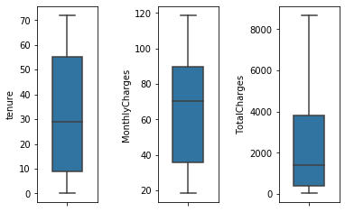

```python
# Box plot for each numerical
data.box_plot_numeric(width=0.5)
```

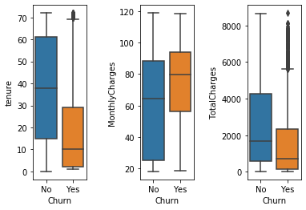

```python
# Box plot by "Churn"
data.box_plot_numeric(target='Churn')
```

The customers who churn tend to have very low tenure, medium -> high MonthlyCharges and very low TotalCharges. the Churn group also look more dense than the non-churn group.

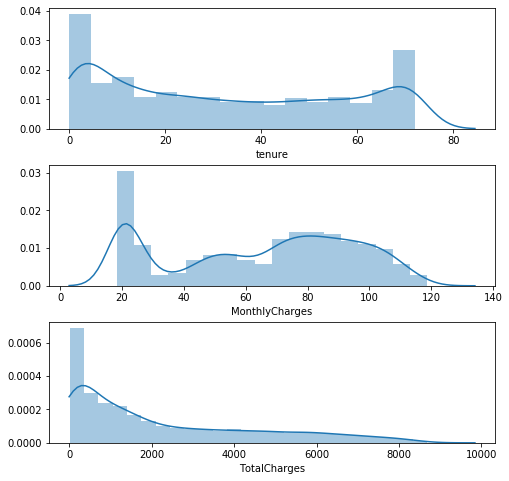

```python
# Histogram and density plot on whole data
data.histogram_and_density(kde=True,kde_kws={'clip': (0,np.inf)})
```

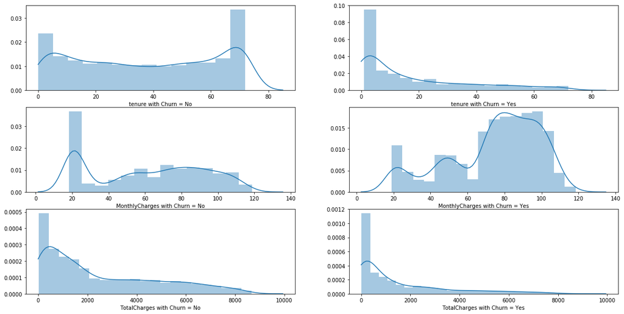

```python
# Histogram and density plot divide by Churn group
data.histogram_and_density(figsize=(20,10),target='Churn',kde=True,kde_kws={'clip': (0,np.inf)})
```

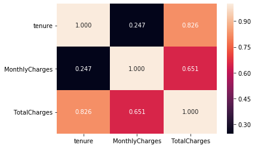

```python
# Correlation matrix of numerical variables
corr = data.correlation_matrix(annot=True,fmt='.3f')
```

## Categorical variables

Descriptive statistic of categorical variables in the dataset:

```python
data.print_descriptive_categorical()
```

Whole dataset

|  | gender | SeniorCitizen | Partner | Dependents | PhoneService | MultipleLines | InternetService | OnlineSecurity | OnlineBackup | DeviceProtection | TechSupport | StreamingTV | StreamingMovies | Contract | PaperlessBilling | PaymentMethod | Churn |
| --- | --- | --- | --- | --- | --- | --- | --- | --- | --- | --- | --- | --- | --- | --- | --- | --- | --- |
| count | 7043 | 7043 | 7043 | 7043 | 7043 | 7043 | 7043 | 7043 | 7043 | 7043 | 7043 | 7043 | 7043 | 7043 | 7043 | 7043 | 7043 |
| unique | 2 | 2 | 2 | 2 | 2 | 3 | 3 | 3 | 3 | 3 | 3 | 3 | 3 | 3 | 2 | 4 | 2 |
| top | Male | 0 | No | No | Yes | No | Fiber optic | No | No | No | No | No | No | Month-to-month | Yes | Electronic check | No |
| freq | 3555 | 5901 | 3641 | 4933 | 6361 | 3390 | 3096 | 3498 | 3088 | 3095 | 3473 | 2810 | 2785 | 3875 | 4171 | 2365 | 5174 |

```python
# Descriptive statistics divided by target column Churn
data.print_descriptive_categorical(target='Churn',style="font-size:110%'")
```

Group Churn:No

|  | gender | SeniorCitizen | Partner | Dependents | PhoneService | MultipleLines | InternetService | OnlineSecurity | OnlineBackup | DeviceProtection | TechSupport | StreamingTV | StreamingMovies | Contract | PaperlessBilling | PaymentMethod | Churn |
| --- | --- | --- | --- | --- | --- | --- | --- | --- | --- | --- | --- | --- | --- | --- | --- | --- | --- |
| count | 5174 | 5174 | 5174 | 5174 | 5174 | 5174 | 5174 | 5174 | 5174 | 5174 | 5174 | 5174 | 5174 | 5174 | 5174 | 5174 | 5174 |
| unique | 2 | 2 | 2 | 2 | 2 | 3 | 3 | 3 | 3 | 3 | 3 | 3 | 3 | 3 | 2 | 4 | 1 |
| top | Male | 0 | Yes | No | Yes | No | DSL | No | Yes | No | No | Yes | Yes | Month-to-month | Yes | Mailed check | No |
| freq | 2625 | 4508 | 2733 | 3390 | 4662 | 2541 | 1962 | 2037 | 1906 | 1884 | 2027 | 1893 | 1914 | 2220 | 2771 | 1304 | 5174 |

Group Churn:Yes

|  | gender | SeniorCitizen | Partner | Dependents | PhoneService | MultipleLines | InternetService | OnlineSecurity | OnlineBackup | DeviceProtection | TechSupport | StreamingTV | StreamingMovies | Contract | PaperlessBilling | PaymentMethod | Churn |
| --- | --- | --- | --- | --- | --- | --- | --- | --- | --- | --- | --- | --- | --- | --- | --- | --- | --- |
| count | 1869 | 1869 | 1869 | 1869 | 1869 | 1869 | 1869 | 1869 | 1869 | 1869 | 1869 | 1869 | 1869 | 1869 | 1869 | 1869 | 1869 |
| unique | 2 | 2 | 2 | 2 | 2 | 3 | 3 | 3 | 3 | 3 | 3 | 3 | 3 | 3 | 2 | 4 | 1 |
| top | Female | 0 | No | No | Yes | Yes | Fiber optic | No | No | No | No | No | No | Month-to-month | Yes | Electronic check | Yes |
| freq | 939 | 1393 | 1200 | 1543 | 1699 | 850 | 1297 | 1461 | 1233 | 1211 | 1446 | 942 | 938 | 1655 | 1400 | 1071 | 1869 |

Here we give some graphs to compare the number in each categorical classes divided by group "Churn".

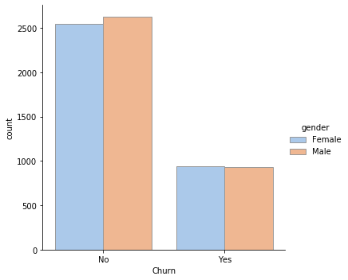

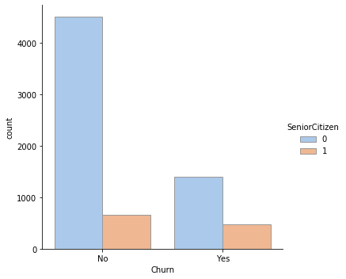

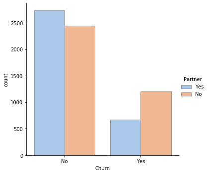

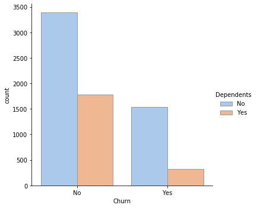

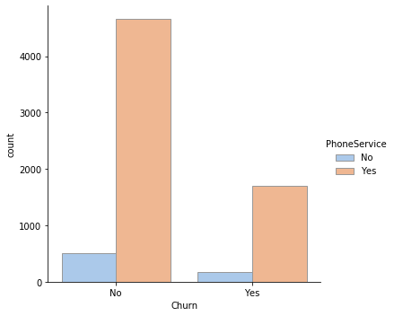

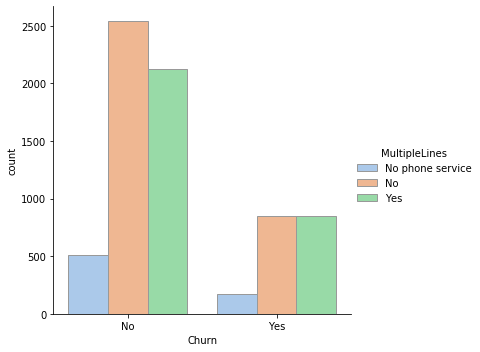

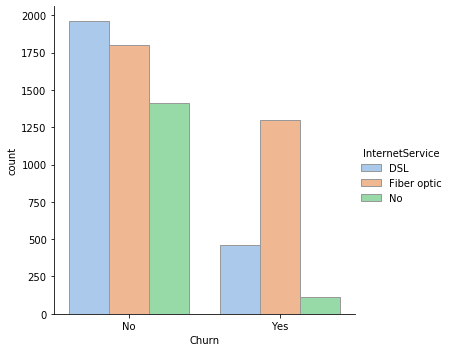

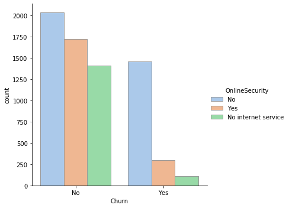

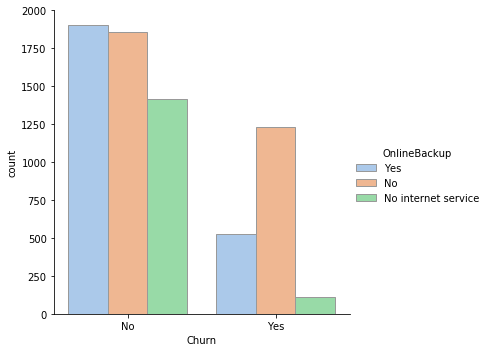

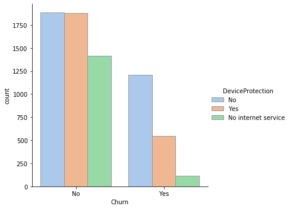

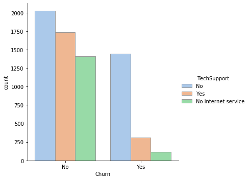

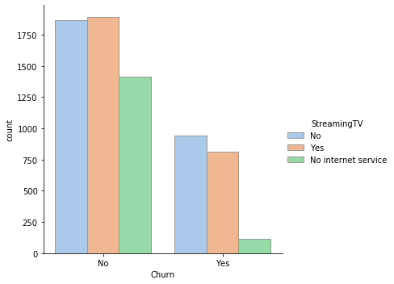

[4 more figures not shown]

```python
# Bar graphs:
data.bar_graphs(target='Churn',palette="pastel", edgecolor=".6")
```

## Summary:

- The customers who churn in dataset tend to have very low tenure, medium -> high MonthlyCharges and very low TotalCharges.
- The Churn group is dense when the non-churn group is very spread out on numerical variables.
- TotalCharges variables should be scaled before using. MonthlyCharges variables should be converted into 3 bins: Low Charges (<40), Medium Charges (40-60), High Charges (>60). Tenure is an ordinal variables and shouble be converted to 4 bins: New Customer (<12), Bronze Customer (12-24), Gold Customer (24-60), Platium Customer (>60)
- Customer with the month-to-month contract has higher probability to churn than other type of contract.
- Customer who received no Tech support has higher probability to churn than customer has tech support.
- Customer who pay by electronic check has higher probability to churn than customer has tech support.